# Analytical Chemistry of Arsenic in Rice

Da Lu, Lauren Okamoto, Dan Piersiak, Nan Wang, Julian Tyson

University of Massachusetts Amherst

Fall 2013

# Abstract

In past years, there has been growing concern regarding the presence of arsenic in rice. The EPA has set a 10ppb limit on drinking water, whereas recent tests by the FDA reveal a highest average concentration of 160ppb in brown rice. An article found in consumer reports produced results with varying concentrations of arsenic in rice collected from the same source. Due to this inconsistency, there is a need for an inexpensive and easy way for the general population to test the arsenic levels of the rice they ingest in their own homes. It is unknown, however, whether arsenic concentrations vary between individual grains of rice.

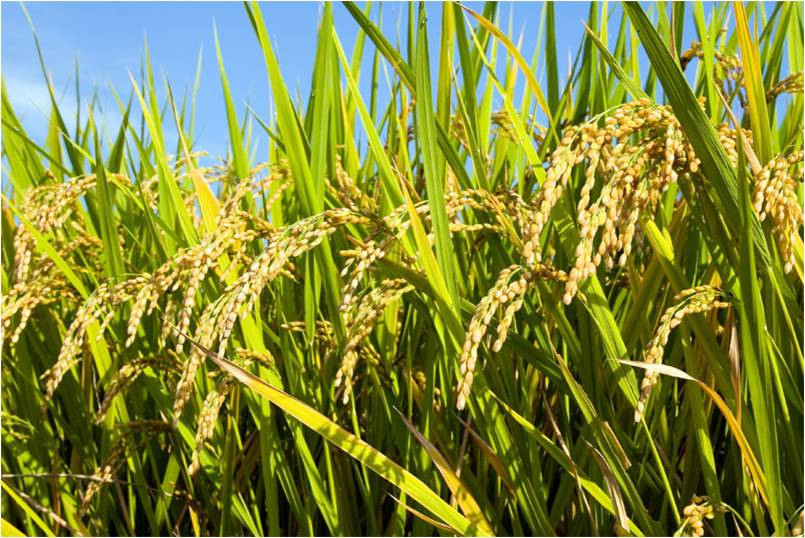

# Introduction

High, potentially harmful levels have been found, particularly, in rice. The Environmental Protection Agency claims there is actually no “safe” level of exposure to inorganic arsenic in rice. Arsenic is a class one carcinogen and over time has been shown to increase the risk of certain cancers. Its sources range from pesticides to naturally occurring compounds in the soil. The most common arsenic compounds found in rice are monomethylarsonate (MMA) and dimethylarsinate (DMA) and arsenic III and V. Sources such as Consumer Reports have established that levels of Arsenic in rice are inconsistent not only by location, but within each crop of rice. Currently, methods exist for the field testing of arsenic in water, however such tests are not readily available for rice.

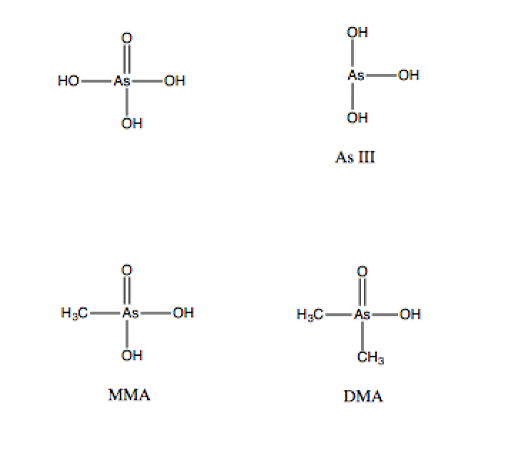

[figure not shown]

# Objectives

- Adapt the HACH test kit for measurement of arsenic in rice in the home.
- To measure arsenic content of individual grains of rice.

# Experimental

In the adaptation of the HACH test kit, rice spiked with a known amount of arsenic was prepared and then extracted. This was done by covering the rice in an arsenic solution and allowing it to dry. Then, the rice was milled to a fine powder in a coffee grinder. A known amount of the powder was added to a warm water, mixed, and the sediment was allowed to settle. The supernatant was then tested using the HACH kit. Several methods were attempted to improve the accuracy of the kit including hydrolysis of the starch, increased test time, and use of an automatic mixer. Digestion of the supernatant with amylase and with hydrochloric acid was also tested.

[figure not shown]

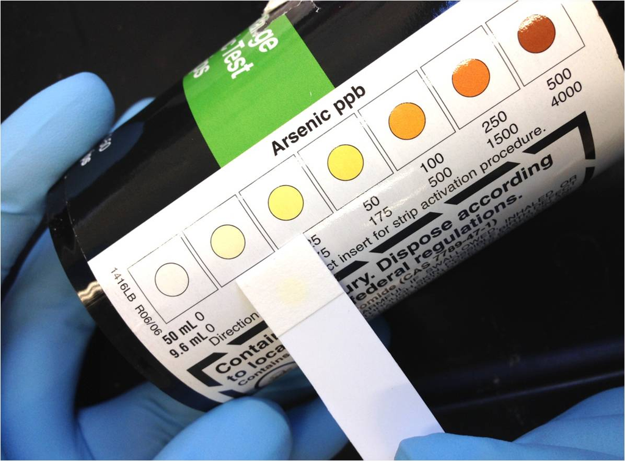

To measure the content of arsenic, the individual grains of Goya enriched rice are weighed, then dissolved in 1ml of concentrated 15.8M nitric acid. After one week of letting the rice completely dissolve, the nitric acid was boiled away using a hotplate, and the remaining solution diluted with 0.5ml of distilled water. The arsenic in the solution is converted from arsenic (III) to arsenic (V) then tested using atomic fluorescence spectrometry. This procedure was modified in order to test more efficiently. Instead of boiling the acid away, the solution was diluted with distilled water to 4.5ml, which contains 2% cysteine. The arsenic was converted, and tested in the instrument. Both methods produced similar results.

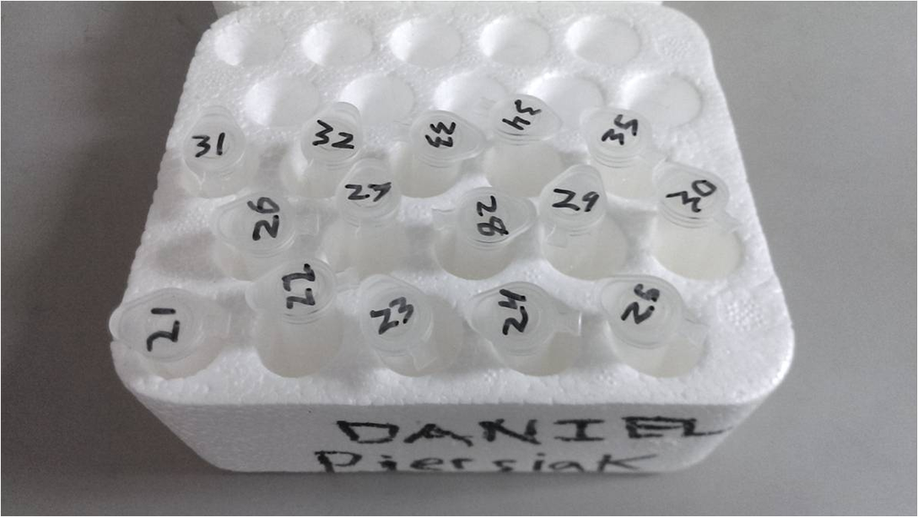

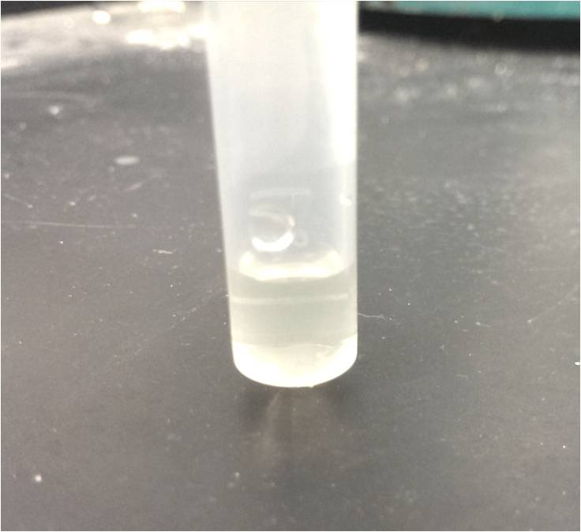

# Results and Discussion

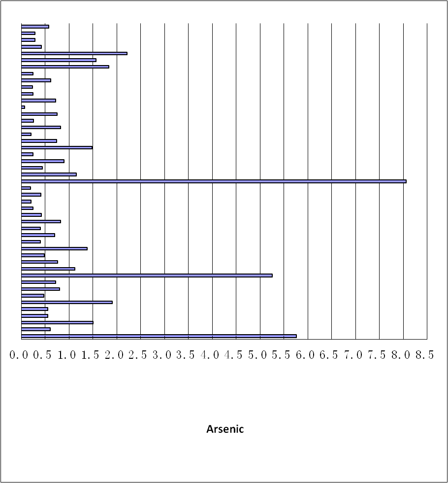

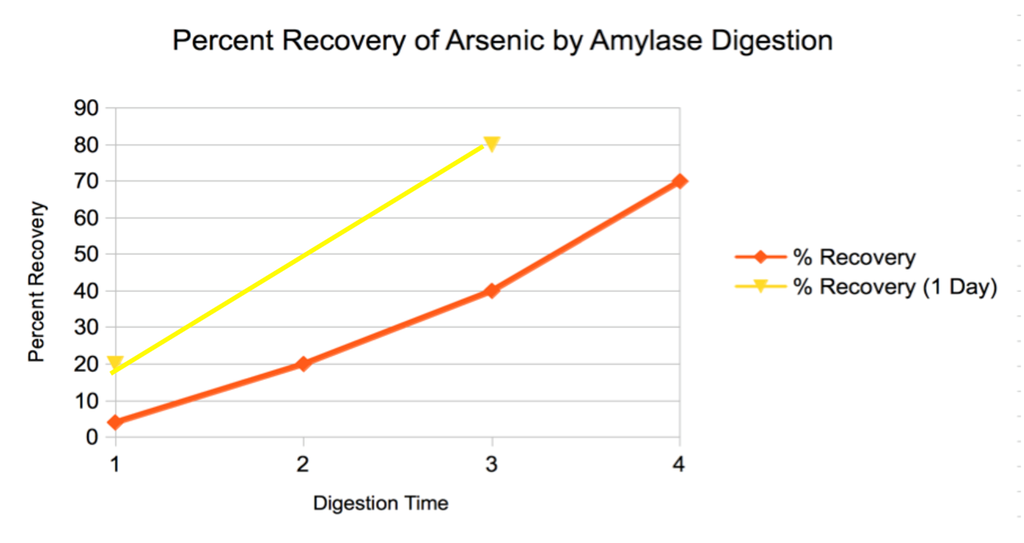

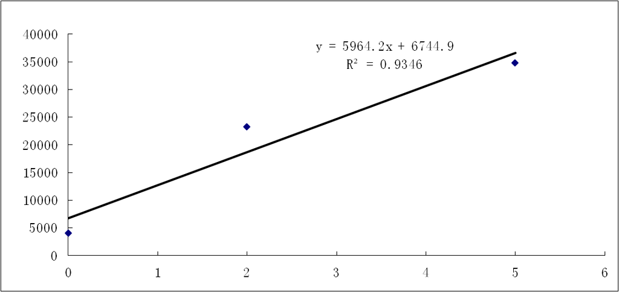

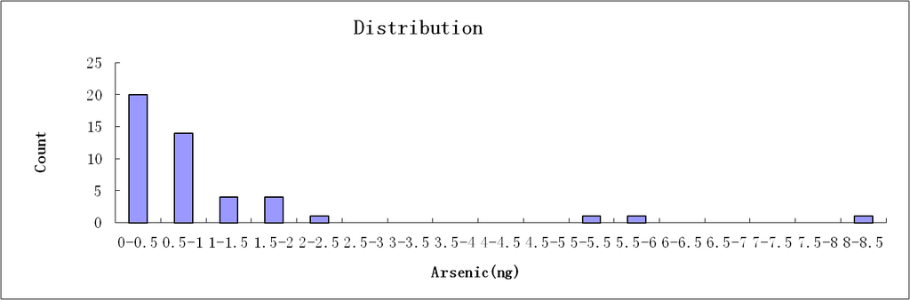

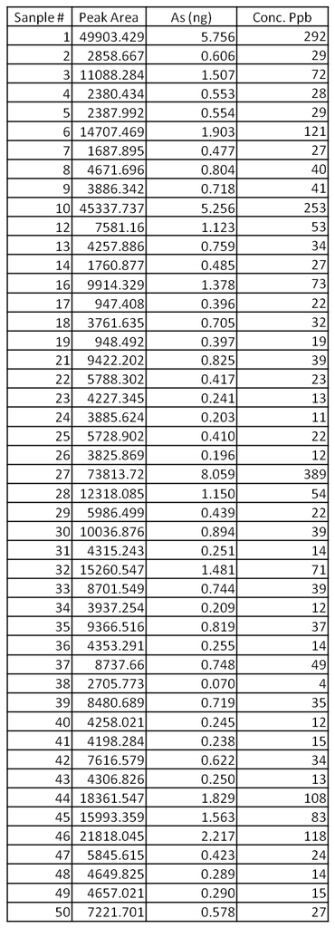

# Conclusion

- HACH kit can be used for the measurement of arsenic in rice with relative accuracy.
- Starch from rice collected with the extracted arsenic interferes with testing process and can be minimized through acid or starch hydrolysis.
- Results of >80% recovery of arsenic content can be obtained through running the kit overnight and >16 hours of starch hydrolysis at 40°C.
- More tests should be run at lower concentrations, around 10ppb.
- 91% of grains contain 0-2ng of arsenic.
- Highest recorded As level in a single grain was 8.059ng.
- Developed a method for measuring arsenic content in singular grains of rice.
- Should test multiple types of rice and more of each type to obtain a larger sample size.

# References

- *Consumer Reports*, 2012 (http://consumerreports.org/cro/arsenicinfood.htm)
- *USA Today* (http://www.usatoday.com/story/news/nation/2013/09/06/arsenic-rice-low-levels-fda/2771903/)